# Homework 03: Coffee grades

Inference for simple linear regression using mathematical models

# Introduction

In this homework you will analyze data from over 1,000 different coffees to explore the relationship between a coffee’s aroma and its flavor grade.

## Learning goals

By the end of the homework you will…

- be able to use mathematical models to conduct inference for the slope
- be able to assess conditions for simple linear regression

# Getting started

- Go to [RStudio](https://rstudio.collegeofidaho.edu) and login with your College of Idaho Email and Password.
- Make a subfolder in your hw directory to store this homework.
- Log into [Canvas](https://cofi.instructure.com/courses/17093/assignments/202861), navigate to Homework 3 and upload the `hw-03.qmd` and `coffee-grades.csv` file into the folder your just made.

# Packages

The following packages are used in the homework.

```r
library(tidyverse)
library(ggformula)
library(broom)
library(knitr)
```

# Data: Coffee grades

The dataset for this homework comes from the [Coffee Quality Database](https://github.com/jldbc/coffee-quality-database) and was obtained from the [#TidyTuesday GitHub repo](https://github.com/rfordatascience/tidytuesday/blob/master/data/2020/2020-07-07/readme.md). It includes information about the origin, producer, measures of various characteristics, and the quality measure for over 1,000 coffees. The coffees can be reasonably be treated as a random sample.

This homework will focus on the following variables:

- `aroma`: Aroma grade, 0 (worst aroma) - 10 (best aroma)
- `flavor`: Flavor grade, 0 (worst flavor) - 10 (best flavor)

[Click here](https://github.com/rfordatascience/tidytuesday/blob/master/data/2020/2020-07-07/readme.md) for the definitions of all variables in the data set. [Click here](http://www.scaa.org/?page=resources&d=cupping-protocols&mod=article_inline) for more details about how these measures are obtained.

```r
coffee <- read_csv("~/MAT-212/hw/hw03/coffee-grades.csv")
```

# Exercises

**Important**

Make sure to do the following as you complete the assignment:

- Write all code and narrative in your Quarto file. I should be able to read all your code in the rendered HTML file.
- Write all narrative in complete sentences.
- Use informative axis titles and labels on all graphs.
- You should periodically **render** your Quarto document to produce the updated HTML file to make sure your output is as you expect it to be.

**Goal**: The goal of this analysis is to use linear regression to understand variability in coffee flavor grades based on the aroma grade.

### Exercise 1

Visualize the relationship between the aroma and flavor grades. Write two observations from the plot.

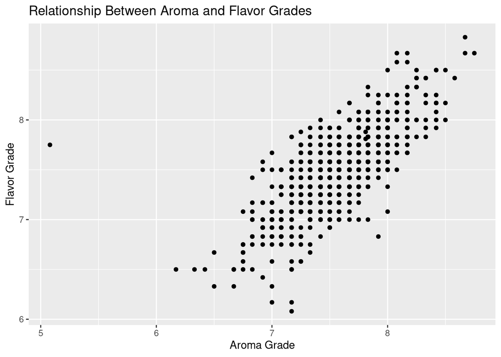

```r
gf_point(flavor ~ aroma, data = coffee) |>
  gf_labs(
    title = "Relationship Between Aroma and Flavor Grades",
    x = "Aroma Grade",
    y = "Flavor Grade"
  )
```

```r
correlation <- cor(coffee$aroma, coffee$flavor) #This correlation part was not parsing the document. Therfore, I had to use ChatGPT to fgure that out. It suggested me the $ to retrive data from a table.
correlation
```

```
[1] 0.7416463
```

There is a positive trend upwards that indicates as aroma grade increases, flavor grade increases as well.

The correlation coefficient seems to be around 0.75 which displays a significant relationship.

### Exercise 2

Fit a linear model using aroma grade to understand variability in the flavor grade. Neatly display the model using three digits and include a **95%** confidence interval for the model slope in the output.

```r
coffee_fit <- lm(flavor ~ aroma, data =coffee)

tidy(coffee_fit, conf.int = TRUE, conf.level = 0.95) |>
  kable(digits = 3)
```

| term | estimate | std.error | statistic | p.value | conf.low | conf.high |
| --- | --- | --- | --- | --- | --- | --- |
| (Intercept) | 1.472 | 0.15 | 9.813 | 0 | 1.178 | 1.766 |
| aroma | 0.800 | 0.02 | 40.397 | 0 | 0.761 | 0.838 |

### Exercise 3

- Interpret the slope in the context of the data.

  For every unit increase in the aroma of the coffee, the flavor of the coffee increases by 0.8 units.
- Assume you are a coffee drinker. Would you drink a coffee represented by the intercept? Why or why not?

### Exercise 4

Input the model name in the code below to calculate the regression standard error, $\hat{\sigma}_\epsilon$. State the definition of this value in the context of the data. Don’t forget to delete `#| eval: false`.

The regression standard error measures the average distance between observed values and the regression line. A smaller value indicates it is closer to the regression line and fits the model well as shown by the regression standard error below.

```r
glance(coffee_fit)$sigma
```

```
[1] 0.2286278
```

### Exercise 5

Do the data provide evidence of a statistically significant linear relationship between aroma and flavor grades? Conduct a hypothesis test using mathematical models to answer this question. In your response

- State the null and alternative hypotheses in words and in mathematical notation.
  - $$H_o : \beta_1 = 0$$

    There is no relationship between the aroma and flavor of the coffee.

    $$H_o : \beta_1 \neq 0$$

    There is a relationship between the aroma and flavor of the coffee.
- What is the test statistic? State what the test statistic means in the context of this problem.

  t-distribution was used to calculate the p-value.
- State the conclusion in the context of the data using a threshold of $\alpha = 0.05$ to make your decision.

  Our p-value is very close to 0 but not zero. This value is way smaller than 0.05 which shows that we have enough evidence to prove a linear relationship between aroma and flavor.

### Exercise 6

- What is the critical value (i.e. $t^*$) used to calculate the 95% confidence interval displayed in Exercise 2 using the `qt` function? Show the code and output used to get your response.

  ```r
  summary(coffee_fit)
  ```

  ```
  Call:
  lm(formula = flavor ~ aroma, data = coffee)

  Residuals:
       Min       1Q   Median       3Q      Max
  -1.12493 -0.11275  0.00132  0.13725  2.21615

  Coefficients:
              Estimate Std. Error t value Pr(>|t|)
  (Intercept)  1.47209    0.15001   9.813   <2e-16 ***
  aroma        0.79956    0.01979  40.397   <2e-16 ***
  ---
  Signif. codes:  0 '***' 0.001 '**' 0.01 '*' 0.05 '.' 0.1 ' ' 1

  Residual standard error: 0.2286 on 1335 degrees of freedom
  Multiple R-squared:   0.55, Adjusted R-squared:  0.5497
  F-statistic:  1632 on 1 and 1335 DF,  p-value: < 2.2e-16
  ```

  ```r
  qt(0.975, df=1335)
  ```

  ```
  [1] 1.961743
  ```

- Is the confidence interval consistent with the conclusions from the hypothesis test? Briefly explain why or why not.

  Yes! in hypothesis, we concluded that there is a relationship between aroma and flavor. And here, we see that the confidence interval (from excercise 2)does not contain zero which further explains the relationship between aroma and flavor.

### Exercise 7

- Calculate the 95% confidence interval for the mean flavor grade for coffees with aroma grade of 7.5. Interpret this value in the context of the data.

  ```r
  newdata <- data.frame(aroma = 7.5)
  predict(coffee_fit, newdata, interval = "confidence", level = 0.95)
  ```

  ```
         fit      lwr     upr
  1 7.468786 7.456202 7.48137
  ```

  95% percent of the time, coffee_fit falls between 7.456202 and 7.48137.
- One coffee produced by the Ethiopia Commodity Exchange has an aroma of 7.5. Calculate the the 95% prediction interval for the flavor grade for this coffee. Interpret this value in the context of the data.

  ```r
  predict(coffee_fit, newdata, interval = "predict", level = 0.95)
  ```

  ```
         fit    lwr      upr
  1 7.468786 7.0201 7.917471
  ```

  The interval is higher. It is because its predicting the range that 95% of the of the items in coffee_fit fall.
- How do the predicted values compare? How do the intervals compare? If there are differences in the predictions and/or intervals, briefly explain why.

  The predicted values were both the same but the interval is larger in prediction than in confidence because prediction considers variability in the line and in the individual data points as well.

### Exercise 8

We’d like to check the model conditions to assess the reliability of the inferential results. To do so, we will create a data frame called `coffee_aug` that includes the residuals and predicted values from the model. Input the name of your model in the code below.

```r
coffee_aug <- augment(coffee_fit)
```

Make a scatter plot of the residuals (`.resid`) vs. fitted values (`.fitted`). Use [`gf_hline()`](https://www.mosaic-web.org/ggformula/reference/gf_lines.html) to add a horizontal dotted line at $residuals = 0$.

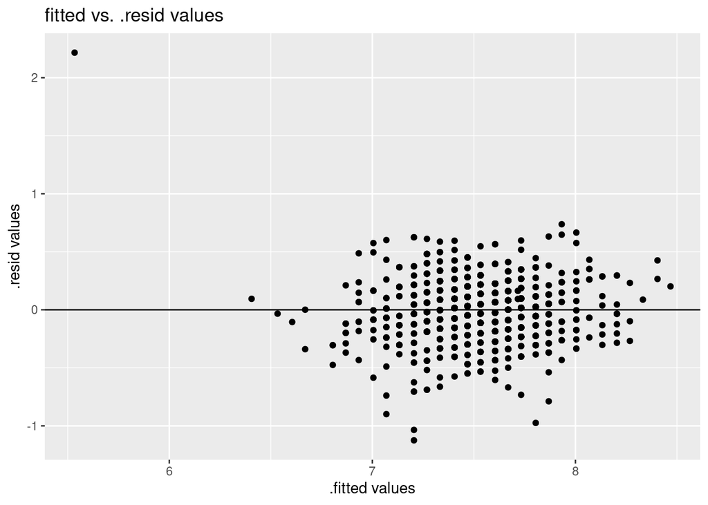

```r
gf_point(.resid ~ .fitted, data =coffee_aug) |>
  gf_hline(yintercept = 0) |>
  gf_labs(
    x = ".fitted values", y = ".resid values",
    title = "fitted vs. .resid values"
  )
```

**Note**

The **linearity condition** is satisfied if there is random scatter of the residuals (no distinguishable pattern or structure) in the plot of residuals vs. fitted values.  
The **constant variance** condition is satisfied if the vertical spread of the residuals is relatively across the plot.

- To what extent is the linearity condition satisfied? Briefly explain why or why not.

  The linearity condition seems to be mehh… satisfied. the plots around the horizontal lines. It has curves around which makes it somewhat satisfied.
- To what extent is the constant variance condition satisfied? Briefly explain why or why not.

  Variance is not that well justified. plots are together at the middle but they fade away and form curves around the edges.

### Exercise 9

**Note**

The **normality** condition is satisfied if the distribution of the residuals is approximately normal. This condition can be relaxed if the sample size is sufficiently large $(n > 30)$.

Make a histogram or density plot of the residuals (`.resid`). Is the normality condition satisfied? Briefly explain why or why not.

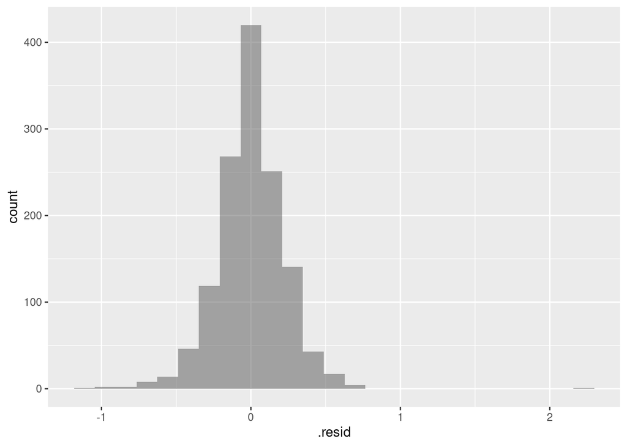

```r
gf_histogram(~.resid, data = coffee_aug)
```

Yes, the normality condition seems to be satisfied because it is making a bell shaped curve or distribution while being centered at 0.

### Exercise 10

**Note**

The **independence** condition means that knowing one residual will not provide information about another. We often check this by assessing whether the observations are independent based on what we know about the subject matter and how the data were collected.

To what extent is the independence condition satisfied? Briefly explain why or why not. You may want to go to the top and look at the source of the data.

It is satisfied as well because the data points are randomly collected and also aroma and flavor are collected independently. This ensures that they do not rely on each another and different data points.

### Exercise 11

Write a paragraph synthesizing the results of this homework. Contextualize the results of the inferential statistics (i.e. hypotheses tests and confidence intervals) with your assessment of the conditions required for them to be valid. Discuss what your results say about the true relationship between aroma and flavor grades along with how trustworthy you think these results are.

We observed a positive liner relationship between aroma and flavor of the coffee beans. every unit increase in aroma, increase the flavor by 0.8 units. The regression standard error was less which indicates closeness with the model. We also confirmed our hypothesis after getting p values really close to 0 (confirmed). Regarding model conditions, linearity, normality and independence conditions were satisfied but the variance condition was not reasonably justified.

# Submission

**Warning**

Before you wrap up the assignment, make sure you have rendered your document and that the HTML file appears as you want it to.

To submit your assignment, upload the .qmd and HTML files to Canvas.

## Grading (23 pts)

| Component | Points |
| --- | --- |
| Ex 1 | 2 |
| Ex 2 | 1 |
| Ex 3 | 2 |
| Ex 4 | 2 |
| Ex 5 | 2 |
| Ex 6 | 2 |
| Ex 7 | 2 |
| Ex 8 | 2 |
| Ex 9 | 2 |
| Ex 10 | 2 |
| Ex 11 | 2 |
| Grammar & Writing | 1[^1] |
| Workflow & formatting | 1[^2] |

## Footnotes

[^1]: The “Grammar & Writing” grade is decided based on your grammar and writing. This is typically decided by choosing one of the questions and assessing the writing.
[^2]: The “Workflow & formatting” grade is to assess the reproducible workflow and document format. This includes having a neatly organized document with readable code and your name and the date in the YAML.